## In this project we are dealling with baseball players data, we have several csv files which each have speciic information aboutthe players and managers(which mainly were player before).

### i was intrested in looking at players data including their demographic, salaries, player characteristics, awards and find the players which have won awards and are common through all those datasets, then finding relationships between their salaries and other variables and also find some relationships between number of wins and loses and other variables

```python
import numpy as np
import pandas as pd
import os
%matplotlib inline
import matplotlib.pyplot as plt
import plotly
import plotly.plotly as py
import seaborn as sns
import statsmodels.api as sm
lowess = sm.nonparametric.lowess
```

# change working directory

```python
os.chdir('D:/DATA_ANALYSIS_NANO_PLUS_DEGREE/Baseball project/Dataset/')
```

# list all available files inside the directory

```python
onlyfiles = os.listdir('D:/DATA_ANALYSIS_NANO_PLUS_DEGREE/Baseball project/Dataset/')
onlyfiles
```

```
['AllstarFull.csv',
 'Appearances.csv',
 'AwardsManagers.csv',
 'AwardsPlayers.csv',
 'AwardsShareManagers.csv',
 'AwardsSharePlayers.csv',
 'Batting.csv',
 'BattingPost.csv',
 'CollegePlaying.csv',
 'corr.csv',
 'Datasets contents.rtf',
 'Fielding.csv',
 'FieldingOF.csv',
 'FieldingPost.csv',
 'HallOfFame.csv',
 'HomeGames.csv',
 'Managers.csv',
 'ManagersHalf.csv',
 'Master.csv',
 'Parks.csv',
 'Pitching.csv',
 'PitchingPost.csv',
 'readme2014.txt',
 'Salaries.csv',
 'Schools.csv',
 'SeriesPost.csv',
 'Teams.csv',
 'TeamsFranchises.csv',
 'TeamsHalf.csv',
 'test_baseball.csv',
 'test_baseball1.csv',
 '~$tasets contents.rtf']
```

## Reading interesting Datafiles

### i have defined a function which will read the csv files, then for any given csv file exist in a list, will read the file and remove the '.csv' and read the dataset into it, at the end i will add all of those variables into a dictionary. for example if the csv file name is Salaries.csv it will read into a variable called Salaries, then i used a for loop which will take all keys and their values from the dictionary and save them as a seperate list.

```python
# defining a function to read csv files for simplicity and avoiding repititive codes
def read_csv(fileName):
    return pd.read_csv(fileName , sep=',')
files = {}
names = ['AllstarFull.csv','Appearances.csv','AwardsPlayers.csv','Salaries.csv','Batting.csv' , 'Master.csv' , 'FieldingPost.csv', 'Pitching.csv']
for name in names:
    files[name.replace(".csv","")] = read_csv(name)

for key,val in files.items():
    exec(key + '=val')
```

## Merging DataFiles

### I Have merged datasets based on PrimaryKeys which here was PlayerID and for some dataframes as we had duplicate column names i have used those names also for merging, like yearID or teamID

```python
merged = Batting.merge(Pitching , how = 'inner' , on = ['playerID','teamID','yearID','stint'])
merged = merged.merge(AwardsPlayers , how = 'inner' , on =  ['playerID'])
merged = merged.merge(FieldingPost, how = 'inner', on = ['playerID','teamID'])
merged = merged.merge(Salaries , how = 'inner' , on = ['playerID','teamID','yearID'])
merged = merged.merge(AllstarFull, how = 'inner' , on = ['playerID','teamID','yearID'])
merged = merged.merge(Master , how = 'inner' , on = ['playerID'])
```

```python
merged.to_csv('D:/DATA_ANALYSIS_NANO_PLUS_DEGREE/Baseball project/Dataset/test_baseball1.csv' , sep=',' , index=False)
```

# Wrangling and Exploration phase for Merged data

```python
merged.info()
```

```
<class 'pandas.core.frame.DataFrame'>
Int64Index: 25165 entries, 0 to 25164
Data columns (total 98 columns):
playerID        25165 non-null object
yearID_x        25165 non-null int64
stint           25165 non-null int64
teamID          25165 non-null object
lgID_x          25165 non-null object
G_x             25165 non-null int64
AB              22527 non-null float64
R_x             22527 non-null float64
H_x             22527 non-null float64
2B              22527 non-null float64
3B              22527 non-null float64
HR_x            22527 non-null float64
RBI             22527 non-null float64
SB_x            22527 non-null float64
CS_x            22527 non-null float64
BB_x            22527 non-null float64
SO_x            22527 non-null float64
IBB_x           22527 non-null float64
HBP_x           22527 non-null float64
SH_x            22527 non-null float64
SF_x            22527 non-null float64
GIDP_x          22527 non-null float64
lgID_y          25165 non-null object
W               25165 non-null int64
L               25165 non-null int64
G_y             25165 non-null int64
GS_x            25165 non-null int64
CG              25165 non-null int64
SHO             25165 non-null int64
SV              25165 non-null int64
IPouts          25165 non-null float64
H_y             25165 non-null int64
ER              25165 non-null int64
HR_y            25165 non-null int64
BB_y            25165 non-null int64
SO_y            25165 non-null int64
BAOpp           23974 non-null float64
```

[output cut: 48 more lines]

```
deathState      64 non-null object
deathCity       64 non-null object
nameFirst       25165 non-null object
nameLast        25165 non-null object
nameGiven       25165 non-null object
weight          25165 non-null float64
height          25165 non-null float64
bats            25165 non-null object
throws          25165 non-null object
debut           25165 non-null object
finalGame       25165 non-null object
retroID         25165 non-null object
bbrefID         25165 non-null object
dtypes: float64(42), int64(27), object(29)
memory usage: 19.0+ MB
```

```python
def getPercentageMissing(data):
    num = merged.isnull().sum()
    return 100*(num/486)
index=getPercentageMissing(merged) > 25.0
merged.drop(index[index.values].keys(), axis=1,inplace=True)
```

```python
merged.info()
```

```
<class 'pandas.core.frame.DataFrame'>
Int64Index: 25165 entries, 0 to 25164
Data columns (total 64 columns):
playerID        25165 non-null object
yearID_x        25165 non-null int64
stint           25165 non-null int64
teamID          25165 non-null object
lgID_x          25165 non-null object
G_x             25165 non-null int64
lgID_y          25165 non-null object
W               25165 non-null int64
L               25165 non-null int64
G_y             25165 non-null int64
GS_x            25165 non-null int64
CG              25165 non-null int64
SHO             25165 non-null int64
SV              25165 non-null int64
IPouts          25165 non-null float64
H_y             25165 non-null int64
ER              25165 non-null int64
HR_y            25165 non-null int64
BB_y            25165 non-null int64
SO_y            25165 non-null int64
ERA             25165 non-null float64
IBB_y           25165 non-null float64
WP              25165 non-null float64
HBP_y           25165 non-null float64
BK              25165 non-null int64
BFP             25165 non-null float64
GF              25165 non-null float64
R_y             25165 non-null int64
awardID         25165 non-null object
yearID_y        25165 non-null int64
lgID_x          25165 non-null object
yearID          25165 non-null int64
lgID_y          25165 non-null object
round           25165 non-null object
POS             25165 non-null object
G               25165 non-null int64
PO              25165 non-null int64
```

[output cut: 14 more lines]

```
birthState      25165 non-null object
birthCity       25165 non-null object
nameFirst       25165 non-null object
nameLast        25165 non-null object
nameGiven       25165 non-null object
weight          25165 non-null float64
height          25165 non-null float64
bats            25165 non-null object
throws          25165 non-null object
debut           25165 non-null object
finalGame       25165 non-null object
retroID         25165 non-null object
bbrefID         25165 non-null object
dtypes: float64(13), int64(27), object(24)
memory usage: 12.5+ MB
```

### we can see there is no more NULL or NA value in the dataset

```python
merged.isnull()
```

[output not shown]

25165 rows × 64 columns

## we can see some of the variables(coloumns) have variance of zero means all the players have same value and we know there is no meaningful information in those variables so will remove them

## Also i have classified players based on their salary in three categories LOW,MEDIUM,HIGH which i got the threshholds from salary column, 0 to first quartile as LOW, first quartile throguh 3rd quartile as MEDIUM, 3rd quartile to maximum value as HIGH

```python
bins = [0,4.250000e+06,1.010000e+07,3.257100e+07]
classes = ['LOW','MEDIUM','HIGH']
merged['salary_class'] = pd.cut(merged['salary'], bins, labels=classes)
```

```python
print merged.salary_class.describe()
```

```
count      25165
unique         3
top       MEDIUM
freq       11972
Name: salary_class, dtype: object
```

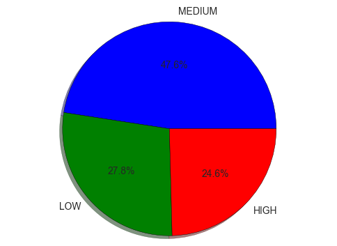

```python
salaries = merged.salary_class.value_counts().reset_index()
salaries.columns = ['class' , 'values']
plt.pie(salaries['values'],labels = salaries['class'],autopct='%1.1f%%', shadow=True)
plt.axis('equal')
plt.show()
```

```python
index=merged.std() == 0.0
merged.drop(index[index.values].keys(), axis=1,inplace=True)
```

```python
merged.corr(method='pearson') >0.75
```

|  | yearID_x | stint | G_x | W | L | G_y | GS_x | CG | SHO | SV | ... | A | E | DP | salary | GP | birthYear | birthMonth | birthDay | weight | height |
| --- | --- | --- | --- | --- | --- | --- | --- | --- | --- | --- | --- | --- | --- | --- | --- | --- | --- | --- | --- | --- | --- |
| yearID_x | True | False | False | False | False | False | False | False | False | False | ... | False | False | False | False | False | False | False | False | False | False |
| stint | False | True | False | False | False | False | False | False | False | False | ... | False | False | False | False | False | False | False | False | False | False |
| G_x | False | False | True | False | False | True | False | False | False | True | ... | False | False | False | False | False | False | False | False | False | False |
| W | False | False | False | True | False | False | True | False | False | False | ... | False | False | False | False | False | False | False | False | False | False |
| L | False | False | False | False | True | False | False | False | False | False | ... | False | False | False | False | False | False | False | False | False | False |
| G_y | False | False | True | False | False | True | False | False | False | True | ... | False | False | False | False | False | False | False | False | False | False |
| GS_x | False | False | False | True | False | False | True | False | False | False | ... | False | False | False | False | False | False | False | False | False | False |
| CG | False | False | False | False | False | False | False | True | True | False | ... | False | False | False | False | False | False | False | False | False | False |
| SHO | False | False | False | False | False | False | False | True | True | False | ... | False | False | False | False | False | False | False | False | False | False |
| SV | False | False | True | False | False | True | False | False | False | True | ... | False | False | False | False | False | False | False | False | False | False |
| IPouts | False | False | False | True | False | False | True | False | False | False | ... | False | False | False | False | False | False | False | False | False | False |
| H_y | False | False | False | True | True | False | True | False | False | False | ... | False | False | False | False | False | False | False | False | False | False |
| ER | False | False | False | True | True | False | True | False | False | False | ... | False | False | False | False | False | False | False | False | False | False |
| HR_y | False | False | False | False | False | False | True | False | False | False | ... | False | False | False | False | False | False | False | False | False | False |
| BB_y | False | False | False | False | False | False | True | False | False | False | ... | False | False | False | False | False | False | False | False | False | False |
| SO_y | False | False | False | True | False | False | True | False | False | False | ... | False | False | False | False | False | False | False | False | False | False |
| ERA | False | False | False | False | False | False | False | False | False | False | ... | False | False | False | False | False | False | False | False | False | False |
| IBB_y | False | False | False | False | False | False | False | False | False | False | ... | False | False | False | False | False | False | False | False | False | False |
| WP | False | False | False | False | False | False | False | False | False | False | ... | False | False | False | False | False | False | False | False | False | False |
| HBP_y | False | False | False | False | False | False | False | False | False | False | ... | False | False | False | False | False | False | False | False | False | False |
| BK | False | False | False | False | False | False | False | False | False | False | ... | False | False | False | False | False | False | False | False | False | False |
| BFP | False | False | False | True | True | False | True | False | False | False | ... | False | False | False | False | False | False | False | False | False | False |
| GF | False | False | True | False | False | True | False | False | False | True | ... | False | False | False | False | False | False | False | False | False | False |
| R_y | False | False | False | True | True | False | True | False | False | False | ... | False | False | False | False | False | False | False | False | False | False |
| yearID_y | False | False | False | False | False | False | False | False | False | False | ... | False | False | False | False | False | False | False | False | False | False |
| yearID | False | False | False | False | False | False | False | False | False | False | ... | False | False | False | True | False | False | False | False | False | False |
| G | False | False | False | False | False | False | False | False | False | False | ... | False | False | False | False | False | False | False | False | False | False |
| PO | False | False | False | False | False | False | False | False | False | False | ... | False | False | False | False | False | False | False | False | False | False |
| A | False | False | False | False | False | False | False | False | False | False | ... | True | False | False | False | False | False | False | False | False | False |
| E | False | False | False | False | False | False | False | False | False | False | ... | False | True | False | False | False | False | False | False | False | False |
| DP | False | False | False | False | False | False | False | False | False | False | ... | False | False | True | False | False | False | False | False | False | False |
| salary | False | False | False | False | False | False | False | False | False | False | ... | False | False | False | True | False | False | False | False | False | False |
| GP | False | False | False | False | False | False | False | False | False | False | ... | False | False | False | False | True | False | False | False | False | False |
| birthYear | False | False | False | False | False | False | False | False | False | False | ... | False | False | False | False | False | True | False | False | False | False |
| birthMonth | False | False | False | False | False | False | False | False | False | False | ... | False | False | False | False | False | False | True | False | False | False |
| birthDay | False | False | False | False | False | False | False | False | False | False | ... | False | False | False | False | False | False | False | True | False | False |
| weight | False | False | False | False | False | False | False | False | False | False | ... | False | False | False | False | False | False | False | False | True | True |
| height | False | False | False | False | False | False | False | False | False | False | ... | False | False | False | False | False | False | False | False | True | True |

38 rows × 38 columns

# i was intrested to see which variables are corrolated with the salary

```python
a = merged.corr(method='pearson') >0.25
```

```python
a.salary
```

[output not shown]

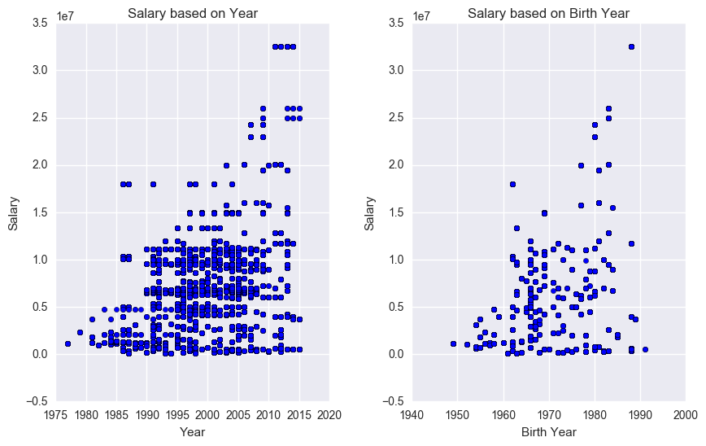

```python
fig, (a,b) = plt.subplots(1,2,figsize=(10, 6))
a.scatter(merged['yearID_y'],merged['salary'] )
a.set_xlabel("Year")
a.set_ylabel("Salary")
a.set_title("Salary based on Year")
b.scatter(merged['birthYear'],merged['salary'] )
b.set_xlabel("Birth Year")
b.set_ylabel("Salary")
b.set_title("Salary based on Birth Year")
fig.subplots_adjust(hspace = 0.5 , wspace = 0.3)
```

```python
Batting.iloc[:,6:].corr(method='pearson')
```

|  | AB | R | H | 2B | 3B | HR | RBI | SB | CS | BB | SO | IBB | HBP | SH | SF | GIDP |
| --- | --- | --- | --- | --- | --- | --- | --- | --- | --- | --- | --- | --- | --- | --- | --- | --- |
| AB | 1.000000 | 0.950973 | 0.987312 | 0.929086 | 0.711915 | 0.689583 | 0.919150 | 0.602521 | 0.682560 | 0.866973 | 0.819089 | 0.637314 | 0.625348 | 0.500656 | 0.803583 | 0.868972 |
| R | 0.950973 | 1.000000 | 0.966463 | 0.917910 | 0.742934 | 0.723842 | 0.923072 | 0.657821 | 0.683213 | 0.889075 | 0.768581 | 0.645149 | 0.636861 | 0.448621 | 0.784240 | 0.810634 |
| H | 0.987312 | 0.966463 | 1.000000 | 0.945326 | 0.735753 | 0.698043 | 0.934702 | 0.610866 | 0.686499 | 0.863757 | 0.777413 | 0.650866 | 0.621093 | 0.482565 | 0.803769 | 0.861458 |
| 2B | 0.929086 | 0.917910 | 0.945326 | 1.000000 | 0.652233 | 0.719772 | 0.915200 | 0.522245 | 0.613252 | 0.830856 | 0.775100 | 0.630030 | 0.598783 | 0.392423 | 0.786475 | 0.827089 |
| 3B | 0.711915 | 0.742934 | 0.735753 | 0.652233 | 1.000000 | 0.341271 | 0.659402 | 0.613622 | 0.652677 | 0.589784 | 0.449108 | 0.402967 | 0.444970 | 0.525831 | 0.526516 | 0.547360 |
| HR | 0.689583 | 0.723842 | 0.698043 | 0.719772 | 0.341271 | 1.000000 | 0.833147 | 0.256216 | 0.366609 | 0.726364 | 0.790554 | 0.665754 | 0.481898 | 0.050490 | 0.697388 | 0.690161 |
| RBI | 0.919150 | 0.923072 | 0.934702 | 0.915200 | 0.659402 | 0.833147 | 1.000000 | 0.501424 | 0.555778 | 0.853383 | 0.789303 | 0.697137 | 0.601970 | 0.361164 | 0.829233 | 0.838809 |
| SB | 0.602521 | 0.657821 | 0.610866 | 0.522245 | 0.613622 | 0.256216 | 0.501424 | 1.000000 | 0.789324 | 0.534996 | 0.435791 | 0.288021 | 0.446851 | 0.429918 | 0.403140 | 0.377281 |
| CS | 0.682560 | 0.683213 | 0.686499 | 0.613252 | 0.652677 | 0.366609 | 0.555778 | 0.789324 | 1.000000 | 0.594440 | 0.514342 | 0.357535 | 0.418645 | 0.452689 | 0.485987 | 0.498399 |
| BB | 0.866973 | 0.889075 | 0.863757 | 0.830856 | 0.589784 | 0.726364 | 0.853383 | 0.534996 | 0.594440 | 1.000000 | 0.767768 | 0.712157 | 0.570218 | 0.370216 | 0.738509 | 0.751492 |
| SO | 0.819089 | 0.768581 | 0.777413 | 0.775100 | 0.449108 | 0.790554 | 0.789303 | 0.435791 | 0.514342 | 0.767768 | 1.000000 | 0.568483 | 0.583631 | 0.237861 | 0.702611 | 0.728592 |
| IBB | 0.637314 | 0.645149 | 0.650866 | 0.630030 | 0.402967 | 0.665754 | 0.697137 | 0.288021 | 0.357535 | 0.712157 | 0.568483 | 1.000000 | 0.402747 | 0.066494 | 0.569121 | 0.585722 |
| HBP | 0.625348 | 0.636861 | 0.621093 | 0.598783 | 0.444970 | 0.481898 | 0.601970 | 0.446851 | 0.418645 | 0.570218 | 0.583631 | 0.402747 | 1.000000 | 0.292538 | 0.521388 | 0.543965 |
| SH | 0.500656 | 0.448621 | 0.482565 | 0.392423 | 0.525831 | 0.050490 | 0.361164 | 0.429918 | 0.452689 | 0.370216 | 0.237861 | 0.066494 | 0.292538 | 1.000000 | 0.208952 | 0.296661 |
| SF | 0.803583 | 0.784240 | 0.803769 | 0.786475 | 0.526516 | 0.697388 | 0.829233 | 0.403140 | 0.485987 | 0.738509 | 0.702611 | 0.569121 | 0.521388 | 0.208952 | 1.000000 | 0.733470 |
| GIDP | 0.868972 | 0.810634 | 0.861458 | 0.827089 | 0.547360 | 0.690161 | 0.838809 | 0.377281 | 0.498399 | 0.751492 | 0.728592 | 0.585722 | 0.543965 | 0.296661 | 0.733470 | 1.000000 |

#### when player is in batting position we can see AB = at batting position is highly correlated with variables like(R = runs abd H =hits ) which make sense due to being in batting position gives you the chance to hit and then do the run,

#### also we can see correlation gradually dropping for variables(2B= double hit and 3B = tripple hit respectively) as we can imagine having a double hit is more likely to happen when at batting position than a tripple hits.

```python
data_numeric = merged._get_numeric_data()
data_numeric['salary_class'] = merged.salary_class
```

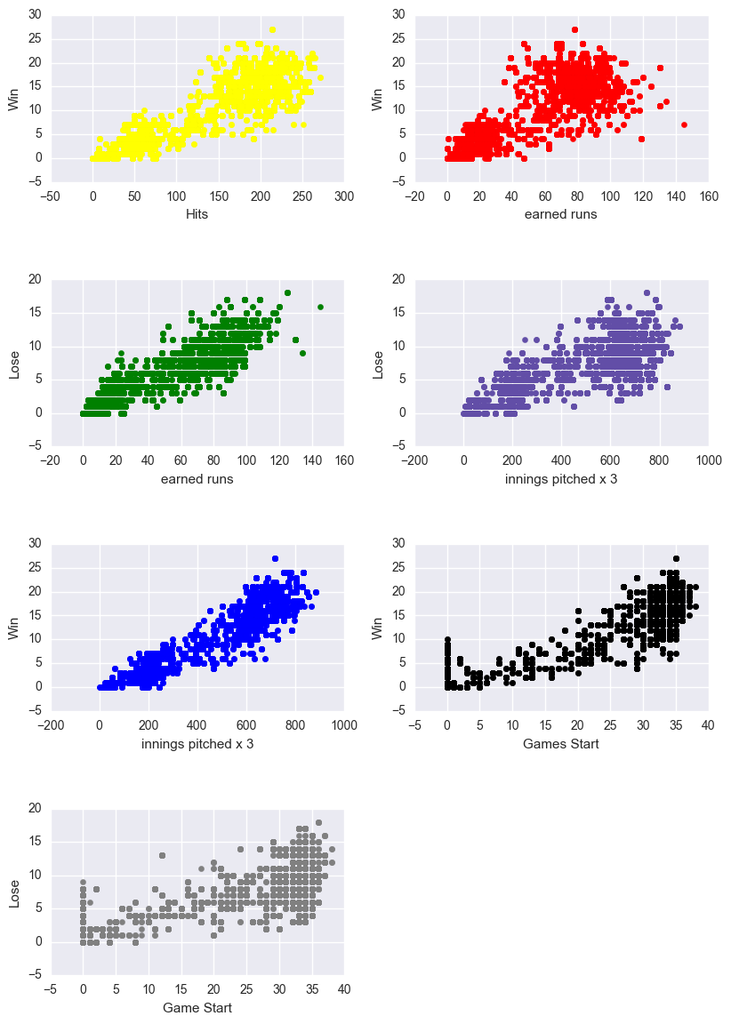

```python
plt.subplot(421)
plt.scatter(data_numeric['H_y'],data_numeric['W'],color= 'yellow')
plt.xlabel('Hits')
plt.ylabel('Win')
plt.grid(True)
plt.tight_layout(pad=0.4, w_pad=4, h_pad=4,rect=[1, 0, 2, 2])

plt.subplot(422)
plt.scatter(data_numeric['ER'],data_numeric['W'],color= 'red')
plt.xlabel('earned runs')
plt.ylabel('Win')
plt.grid(True)

plt.subplot(423)
plt.scatter(data_numeric['ER'],data_numeric['L'],color= 'green')
plt.xlabel('earned runs')
plt.ylabel('Lose')
plt.grid(True)

plt.subplot(424)
plt.scatter(data_numeric['IPouts'],data_numeric['L'],color= '#624ea7')
plt.xlabel('innings pitched x 3')
plt.ylabel('Lose')
plt.grid(True)

plt.subplot(425)
plt.scatter(data_numeric['IPouts'],data_numeric['W'],color= 'blue')
plt.xlabel('innings pitched x 3')
plt.ylabel('Win')
plt.grid(True)

plt.subplot(426)
plt.scatter(data_numeric['GS_x'],data_numeric['W'],color= 'black')
plt.xlabel('Games Start')
plt.ylabel('Win')
plt.grid(True)

plt.subplot(427)
plt.scatter(data_numeric['GS_x'],data_numeric['L'],color= 'grey')
plt.xlabel('Game Start')
plt.ylabel('Lose')
plt.grid(True)
```

## as we can see based on the scatter plot, The number of wins increases as number of Hits increase, also more earned runs will casue in both wins and loses which if we look at the numbers increasing the earned runs will ending up in higher numbers of wins than loses, and we can see there are noises in number of loses based on earned runns which might be randoms, which this condition is also for innings pitched and Game Start.

## Also we can see for both win and lose based on game start we have increase in number of los and wins while the game start value is 0 which is because some teams might have been guest and did not start a game for couple a weeks

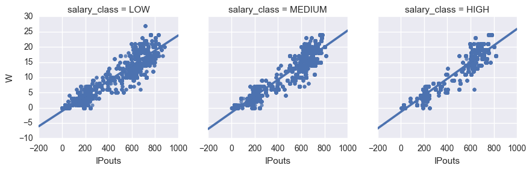

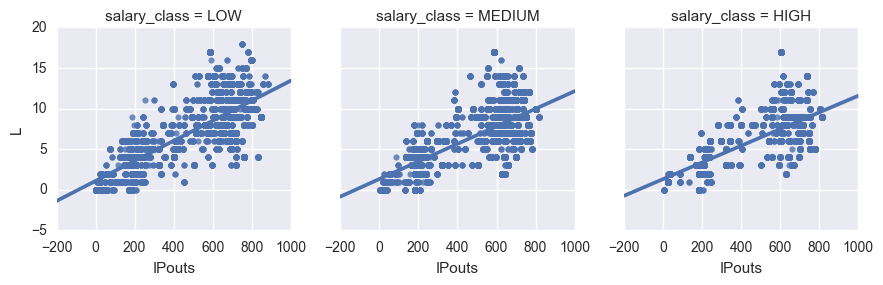

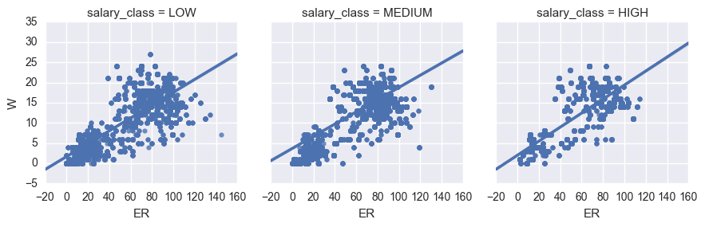

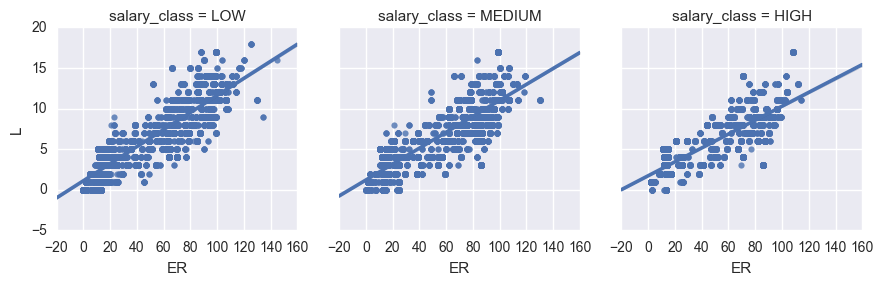

```python
sns.lmplot(x = "IPouts" , y ="W" , col="salary_class" , data = data_numeric , size= 3 , col_wrap=3)
sns.lmplot(x = "IPouts" , y ="L" , col="salary_class" , data = data_numeric , size= 3 , col_wrap=3)
sns.lmplot(x = "ER" , y ="W" , col="salary_class" , data = data_numeric , size= 3 , col_wrap=3)
sns.lmplot(x = "ER" , y ="L" , col="salary_class" , data = data_numeric , size= 3 , col_wrap=3)
```

## by using salary_class variable and using a linear relation between Los, Win, ER, Ipouts we can see the following results:

### 1- we have a good linear relation between IPouts and number of wins but for Ipouts and number of lost games we can see there exists random noises and relation is not linear it can be quadtratic as it seems to have a curve

### 2- we also can find a linear relation between win and ER wich we also have some linear relation between ER and lose but we can see the number of lost are much less than number of wins, basically e=increasing in ER leading to more number of wins than lose

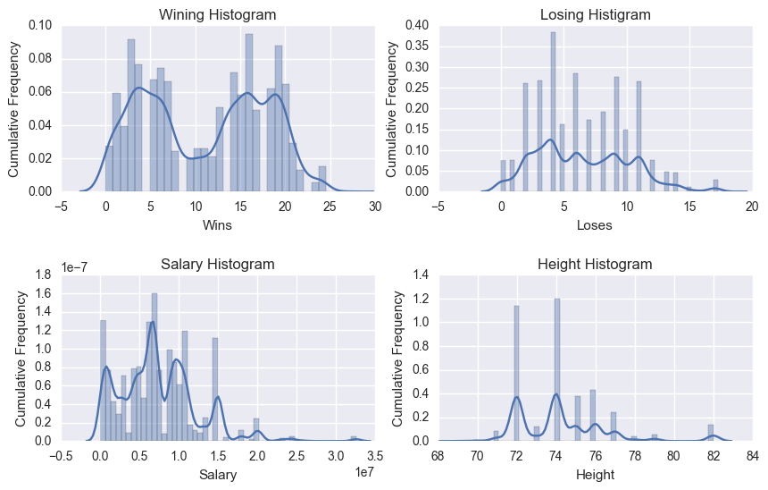

```python
# fig, axs = plt.subplots(ncols=2, figsize=(10, 4))
fig, ((a,b),(c,d)) = plt.subplots(2,2,figsize=(10, 6),)
sns.distplot(data_numeric['W'] , ax=a)
a.set_xlabel('Wins')
a.set_ylabel('Cumulative Frequency')
a.set_title('Wining Histogram')
sns.distplot(data_numeric['L'] , ax = b)
b.set_xlabel('Loses')
b.set_ylabel('Cumulative Frequency')
b.set_title('Losing Histigram')
sns.distplot(data_numeric['salary'],ax = c)
c.set_xlabel('Salary')
c.set_ylabel('Cumulative Frequency')
c.set_title('Salary Histogram')
sns.distplot(data_numeric['height'] , ax = d)
d.set_xlabel('Height')
d.set_ylabel('Cumulative Frequency')
d.set_title('Height Histogram')
fig.subplots_adjust(hspace = 0.5,wspace = 0.2)
```

## we can see yearID has a positive correlation with salary which make sense as we are getting closer to present the salaries have also increased which we can see for players which are younger we have higher salaries.

# Conclusion :

### 2- For winining we have found several variables which were highly correlated ( greater than 0.75 ) as we know correlation does not mean causation i have also found linear relations between wins and for example number of Hits, Ipouts and Earned Rounds.

### 3- For Losing also we have found some variables with high correlations ( greater than 0.75) as we know correlation does not mean causation i also have found Ipouts and Earned rounds have a linear relations with number of loses.

## what we can see here is Earned rounds and Ipouts bouth increase in win and lose, but if we look at the plots we can see we have much more increases in number of wins than loses.

# Limitation/Discussion:

### we had multiple dataset which some of them did not have any important information relating to our goal, also we have high missing values for some variables which we ending up to removing the variables, which might have a good impact for reaching the goal.